# Project: Identify Customer Segments

### Step 3.3: Compare Customer Data to Demographics Data

At this point, you have clustered data based on demographics of the general population of Germany, and seen how the customer data for a mail-order sales company maps onto those demographic clusters. In this final substep, you will compare the two cluster distributions to see where the strongest customer base for the company is.

Consider the proportion of persons in each cluster for the general population, and the proportions for the customers. If we think the company's customer base to be universal, then the cluster assignment proportions should be fairly similar between the two. If there are only particular segments of the population that are interested in the company's products, then we should see a mismatch from one to the other. If there is a higher proportion of persons in a cluster for the customer data compared to the general population (e.g. 5% of persons are assigned to a cluster for the general population, but 15% of the customer data is closest to that cluster's centroid) then that suggests the people in that cluster to be a target audience for the company. On the other hand, the proportion of the data in a cluster being larger in the general population than the customer data (e.g. only 2% of customers closest to a population centroid that captures 6% of the data) suggests that group of persons to be outside of the target demographics.

Take a look at the following points in this step:

- Compute the proportion of data points in each cluster for the general population and the customer data. Visualizations will be useful here: both for the individual dataset proportions, but also to visualize the ratios in cluster representation between groups. Seaborn's [`countplot()`](https://seaborn.pydata.org/generated/seaborn.countplot.html) or [`barplot()`](https://seaborn.pydata.org/generated/seaborn.barplot.html) function could be handy.
  - Recall the analysis you performed in step 1.1.3 of the project, where you separated out certain data points from the dataset if they had more than a specified threshold of missing values. If you found that this group was qualitatively different from the main bulk of the data, you should treat this as an additional data cluster in this analysis. Make sure that you account for the number of data points in this subset, for both the general population and customer datasets, when making your computations!
- Which cluster or clusters are overrepresented in the customer dataset compared to the general population? Select at least one such cluster and infer what kind of people might be represented by that cluster. Use the principal component interpretations from step 2.3 or look at additional components to help you make this inference. Alternatively, you can use the `.inverse_transform()` method of the PCA and StandardScaler objects to transform centroids back to the original data space and interpret the retrieved values directly.
- Perform a similar investigation for the underrepresented clusters. Which cluster or clusters are underrepresented in the customer dataset compared to the general population, and what kinds of people are typified by these clusters?

```python
prediction_azdias_1 = np.append(prediction_azdias, [13] * (len_azdias - len(prediction_azdias)))
```

```python
prediction_customers_1 = np.append(prediction_customers, [13] * (len_customers - len(prediction_customers)))
```

```python
# Compare the proportion of data in each cluster for the customer data to the
# proportion of data in each cluster for the general population.

import matplotlib.ticker as ticker

def plot_distribution(df, column, height):
    ncount = len(df)
    plt.figure(figsize=(14,6))
    ax = sns.countplot(x = column, data = df)
    plt.title('Distribution of each Cluster')
    plt.xlabel('Cluster Tag')

    # Make twin axis
    ax2=ax.twinx()

    # Switch so count axis is on right, frequency on left
    ax2.yaxis.tick_left()
    ax.yaxis.tick_right()

    # Also switch the labels over
    ax.yaxis.set_label_position('right')
    ax2.yaxis.set_label_position('left')

    ax2.set_ylabel('Frequency [%]')

    for p in ax.patches:
        x=p.get_bbox().get_points()[:,0]
        y=p.get_bbox().get_points()[1,1]
        ax.annotate('{:.1f}%'.format(100.*y/ncount), (x.mean(), y),
                ha='center', va='bottom') # set the alignment of the text

    # Use a LinearLocator to ensure the correct number of ticks
    ax.yaxis.set_major_locator(ticker.LinearLocator(11))

    # Fix the frequency range to 0-100
    ratio = 100 / height
    ax2.set_ylim(0,100 / ratio)
    ax.set_ylim(0,ncount / ratio)

    # And use a MultipleLocator to ensure a tick spacing of 10
    ax2.yaxis.set_major_locator(ticker.MultipleLocator(10))

    # Need to turn the grid on ax2 off, otherwise the gridlines end up on top of the bars
    ax2.grid(None)
```

```python
df_prediction_azdias_1 = pd.DataFrame(prediction_azdias_1, columns = ['Cluster'])
df_prediction_customers_1 = pd.DataFrame(prediction_customers_1, columns = ['Cluster'])
```

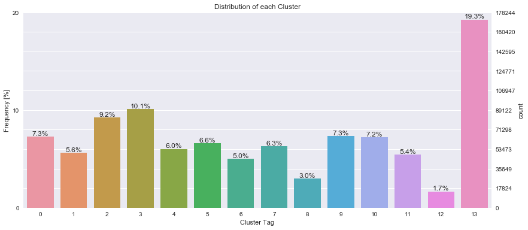

```python
plot_distribution(df_prediction_azdias_1, 'Cluster', height = 20)
```

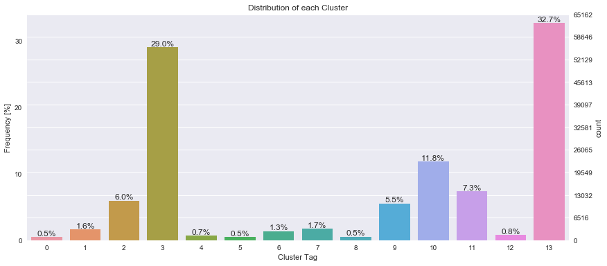

```python
plot_distribution(df_prediction_customers_1, 'Cluster', height = 34)
```

```python
def drop_data(df):
    """
    Perform feature trimming, re-encoding, and engineering for demographics
    data

    INPUT: Demographics DataFrame
    OUTPUT: Trimmed and cleaned demographics DataFrame
    """

    # Put in code here to execute all main cleaning steps:
    # convert missing value codes into NaNs, ...
    feat_info = pd.read_csv('AZDIAS_Feature_Summary.csv', sep = ';')
    for i, column in enumerate(df.columns):
        str_n = feat_info['missing_or_unknown'].iloc[i]
        if i in [57, 58, 59]:
            list_n = str_n[1: -1].split(',')
        else:
            list_n = ast.literal_eval(str_n)
        for num in list_n:
            df[column].replace(num, np.NaN, inplace = True)

    # remove selected columns and rows, ...
    drop_columns = ['TITEL_KZ', 'AGER_TYP', 'GEBURTSJAHR', 'ALTER_HH', 'KK_KUNDENTYP', 'KBA05_BAUMAX']
    df.drop(drop_columns, axis = 1, inplace = True)

    df['Missing_num'] = df.isnull().sum(axis=1)
    df_1 = df[df['Missing_num'] <= 5]
    df_1 = df_1.drop('Missing_num', axis = 1)
    df_1 = new_feature_1(df_1)
    df_1 = new_feature_2(df_1)
    return df_1
```

```python
# Reload dataset and do column/row dropping
azdias = pd.read_csv('Udacity_AZDIAS_Subset.csv', sep=';')
customers = pd.read_csv('Udacity_CUSTOMERS_Subset.csv', sep = ';')
azdias = drop_data(azdias)
customers = drop_data(customers)
```

```python
# What kinds of people are part of a cluster that is overrepresented in the
# customer data compared to the general population?
target_list = df_prediction_customers_1[df_prediction_customers_1['Cluster'] == 3].index
df_target = customers.iloc[target_list]
df_target.head(3)
```

|  | ALTERSKATEGORIE_GROB | ANREDE_KZ | CJT_GESAMTTYP | FINANZ_MINIMALIST | FINANZ_SPARER | FINANZ_VORSORGER | FINANZ_ANLEGER | FINANZ_UNAUFFAELLIGER | FINANZ_HAUSBAUER | FINANZTYP | ... | PLZ8_HHZ | PLZ8_GBZ | ARBEIT | ORTSGR_KLS9 | RELAT_AB | Decade | Movement | Nation | Wealth | Life_Stage |
| --- | --- | --- | --- | --- | --- | --- | --- | --- | --- | --- | --- | --- | --- | --- | --- | --- | --- | --- | --- | --- | --- |
| 0 | 4.0 | 1 | 5.0 | 5 | 1 | 5 | 1 | 2 | 2 | 2 | ... | 5.0 | 5.0 | 1.0 | 2.0 | 1.0 | 50s | Avantgarde | E+W | Wealthy Households | Families With School Age Children |
| 2 | 4.0 | 2 | 2.0 | 5 | 1 | 5 | 1 | 4 | 4 | 2 | ... | 3.0 | 2.0 | 3.0 | 5.0 | 3.0 | 50s | Avantgarde | E+W | Comfortable Households | Older Families & Mature Couples |
| 5 | 3.0 | 1 | 4.0 | 5 | 1 | 5 | 1 | 2 | 3 | 5 | ... | 5.0 | 5.0 | 3.0 | 7.0 | 5.0 | 50s | Avantgarde | E+W | Comfortable Households | Older Families & Mature Couples |

3 rows × 84 columns

```python
# What kinds of people are part of a cluster that is underrepresented in the
# customer data compared to the general population?
outside_list = df_prediction_azdias_1[df_prediction_azdias_1['Cluster'] == 0].index
df_outside = azdias.iloc[outside_list]
df_outside.head(3)
```

|  | ALTERSKATEGORIE_GROB | ANREDE_KZ | CJT_GESAMTTYP | FINANZ_MINIMALIST | FINANZ_SPARER | FINANZ_VORSORGER | FINANZ_ANLEGER | FINANZ_UNAUFFAELLIGER | FINANZ_HAUSBAUER | FINANZTYP | ... | PLZ8_HHZ | PLZ8_GBZ | ARBEIT | ORTSGR_KLS9 | RELAT_AB | Decade | Movement | Nation | Wealth | Life_Stage |
| --- | --- | --- | --- | --- | --- | --- | --- | --- | --- | --- | --- | --- | --- | --- | --- | --- | --- | --- | --- | --- | --- |
| 1 | 1.0 | 2 | 5.0 | 1 | 5 | 2 | 5 | 4 | 5 | 1 | ... | 5.0 | 4.0 | 3.0 | 5.0 | 4.0 | 90s | MainStream | E+W | Poorer Households | Pre-Family Couples & Singles |
| 31 | 2.0 | 2 | 6.0 | 1 | 5 | 2 | 3 | 5 | 4 | 1 | ... | 4.0 | 2.0 | 4.0 | 8.0 | 5.0 | 80s | MainStream | W | Poorer Households | Pre-Family Couples & Singles |
| 43 | 1.0 | 2 | 4.0 | 1 | 5 | 3 | 5 | 5 | 5 | 1 | ... | 4.0 | 4.0 | 3.0 | 7.0 | 2.0 | 90s | MainStream | E+W | Prosperous Households | Elders In Retirement |

3 rows × 84 columns

```python
def plot_comparison(column):
    fig, (ax1, ax2) = plt.subplots(figsize=(12,4), ncols=2)
    sns.countplot(x = column, data=df_target, ax=ax1)
    ax1.set_xlabel('Value')
    ax1.set_title('Distribution of target population')
    sns.countplot(x = column, data=df_outside, ax=ax2)
    ax2.set_xlabel('Value')
    ax2.set_title('Distribution of non-target population')
    fig.tight_layout()
    plt.show()
```

### Discussion 3.3: Compare Customer Data to Demographics Data

By looking at the previous investigation, two most important features from PCA analysis are `LP_STATUS_GROB_1.0` and `FINANZ_MINIMALIST`. Let's take a look at these two features.

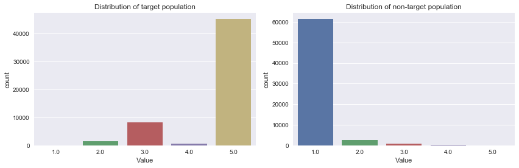

```python
plot_comparison('LP_STATUS_GROB')
```

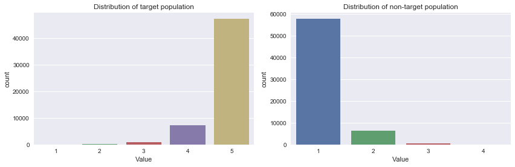

```python
plot_comparison('FINANZ_MINIMALIST')
```

### Discussion 3.3.1: Two Main Features

From the above two set of graphs we can see a clear defference between target and non-target population. The meaning of values for the two features are shown below.

`LP_STATUS_GROB`: Social status, rough scale

- 1: low-income earners (maps to 1-2 in fine scale)
- 2: average earners (maps to 3-5 in fine scale)
- 3: independents (maps to 6-7 in fine scale)
- 4: houseowners (maps to 8-9 in fine scale)
- 5: top earners (maps to 10 in fine scale)

`FINANZ_MINIMALIST`: Financial typology, MINIMALIST: low financial interest:

- -1: unknown
- 1: very high
- 2: high
- 3: average
- 4: low
- 5: very low

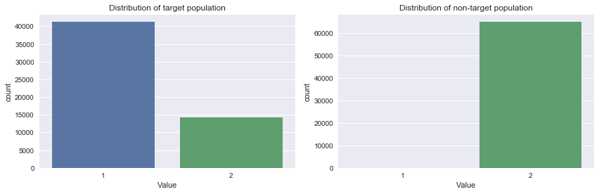

```python
plot_comparison('ANREDE_KZ')
```

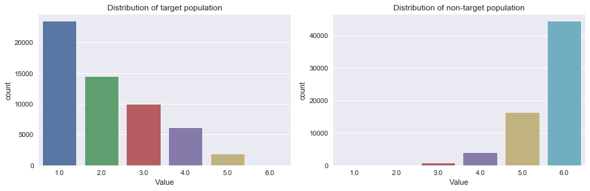

```python
plot_comparison('HH_EINKOMMEN_SCORE')
```

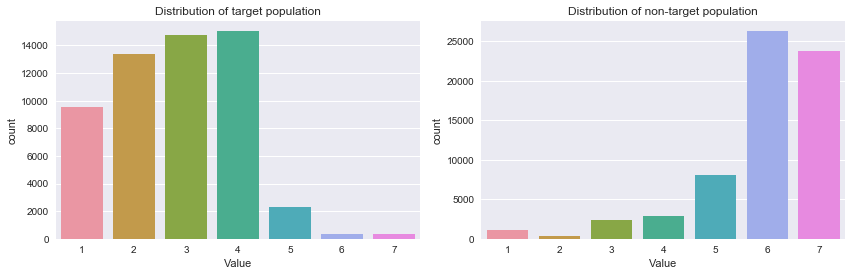

```python
plot_comparison('SEMIO_PFLICHT')
```

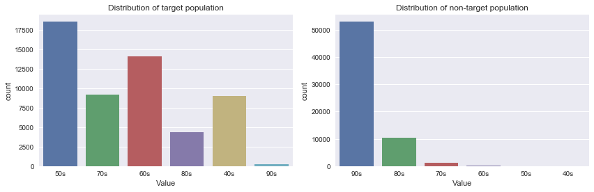

```python
plot_comparison('Decade')
```

### Discussion 3.3.1: Some Other Features

So in this part, I choose some more features which can interpret the difference between clusters.

`ANREDE_KZ`: Gender

- 1: male
- 2: female

The mail-order company prefer male than female, this might infer that males are more likely to purchase through mail promotion.

`HH_EINKOMMEN_SCORE`: Estimated household net income

- 1: highest income
- 2: very high income
- 3: high income
- 4: average income
- 5: lower income
- 6: very low income

This one is another feature which connected to financial property. Similar to pervious features, company perfer higher income customers than lower income ones.

`SEMIO_PFLICHT`: Personality typology_dutiful

- 1: highest affinity
- 2: very high affinity
- 3: high affinity
- 4: average affinity
- 5: low affinity
- 6: very low affinity
- 7: lowest affinity

Person has highest affinity of duriful is target by the company. There are also some other personality related features and show similar result.

`Decade`: This features is achieved by one-hot encoding from the mixed type feature.

From the graph, we can see elder people who was born in 40s - 70s are targeted by the company while 90s are most likely to be outside the target zone.

In conclusion, we should focus on the population who is male, elder, more dutiful, richer and kept lower amount of money in bank.

> Congratulations on making it this far in the project! Before you finish, make sure to check through the entire notebook from top to bottom to make sure that your analysis follows a logical flow and all of your findings are documented in **Discussion** cells. Once you've checked over all of your work, you should export the notebook as an HTML document to submit for evaluation. You can do this from the menu, navigating to **File -> Download as -> HTML (.html)**. You will submit both that document and this notebook for your project submission.